# ESM 263 Assignment 1: Cartography

Linus Blomqvist

1/19/2021

# Task 3: Design a map

First we’ll load the data. The `sf` function `st_read` understands what format the file is so it needs no further specification.

```r
hw1 <- st_read("data/HW1/HW1.gpkg", layer = "CountryWatch")
```

We can verify that we now have an `sf` object:

```r
class(hw1)
```

```
## [1] "sf"         "data.frame"
```

It’s a good idea to check if the data is projected, which it is not. `TRUE` here means that it is in long/lat form, which is not projected.

```r
st_is_longlat(hw1)
```

```
## [1] TRUE
```

For this assignment, I don’t think we need to project the sf object, but we would need to do that if we wanted to calculate things like area.

I will map the greenhouse gas emissions variable. Before I do so, I’ll do some sanity checks, starting with a histogram.

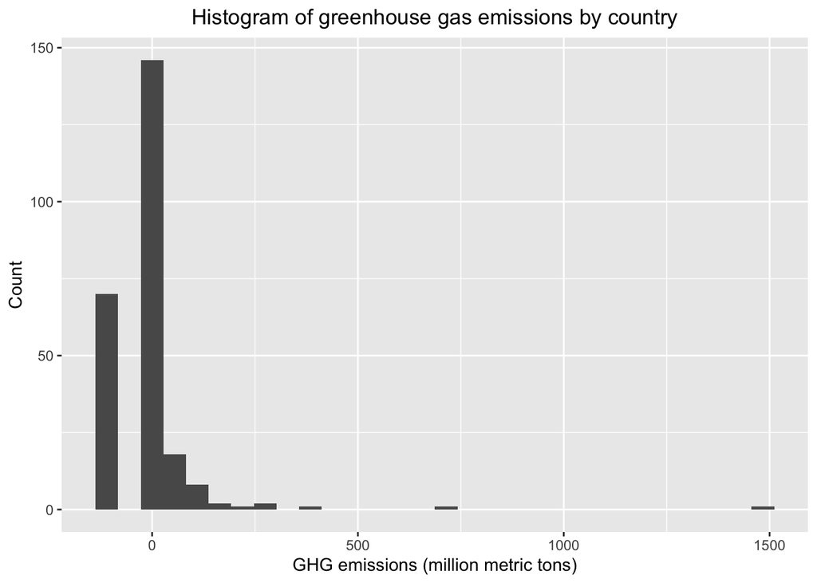

```r
ggplot(hw1, aes(GGAS_EMS98)) +
  geom_histogram() +
  labs(title = "Histogram of greenhouse gas emissions by country", x = "GHG emissions (million metric tons)", y = "Count") +
  theme(plot.title = element_text(hjust = 0.5))
```

There are 70 values below zero and they are all -99.

```r
hw1 %>%
  filter(GGAS_EMS98 < 0) %$%
  unique(GGAS_EMS98)
```

```
## [1] -99
```

According to the documentation, this means there’s no data. This is better represented with `NA`, so I’ll change that. I’ll make a new variable just to preserve the original.

```r
hw1$ggas <- hw1$GGAS_EMS98
hw1$ggas[hw1$ggas < 0] <- NA
```

I’m also curious which countries have the extremely large emissions.

```r
hw1 %>%
  filter(ggas > 300) %$%
  CNTRY_NAME
```

```
## [1] "Russia"        "United States" "China"
```

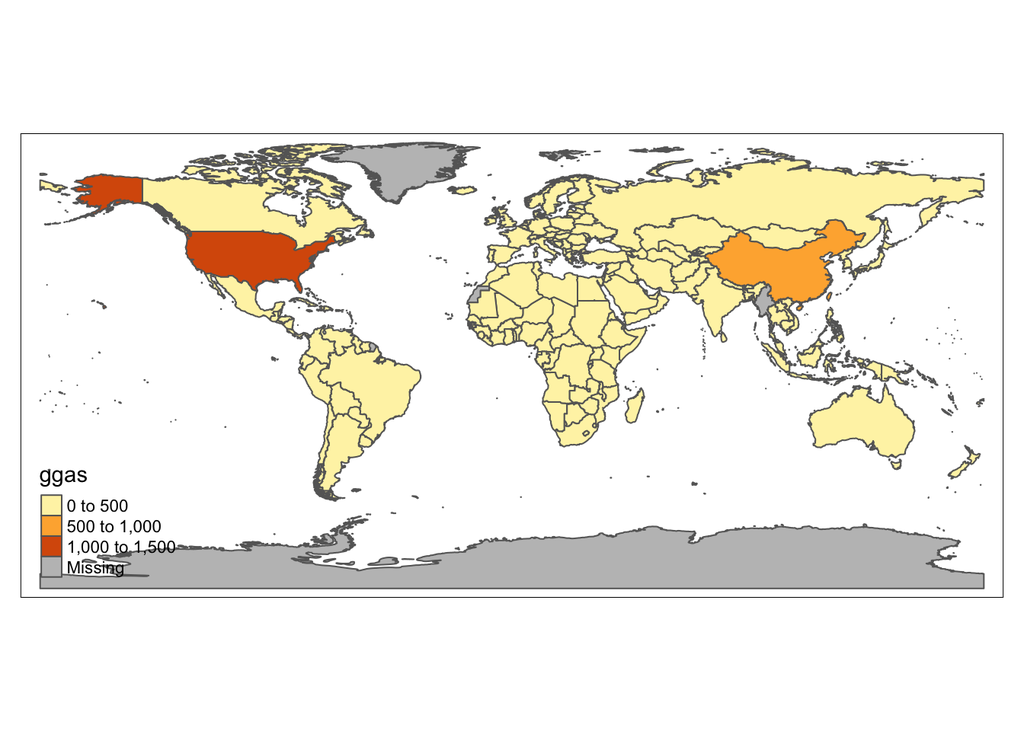

```r
tm_shape(hw1) +
  tm_polygons("ggas")
```

**Considerations/choices:**

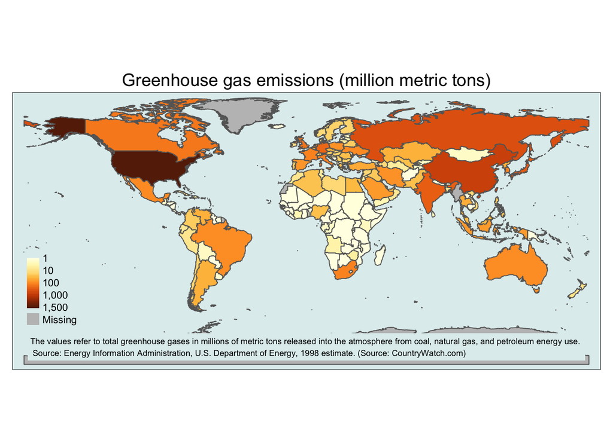

```r
tm_shape(hw1) +
  tm_polygons(col = "GGAS_EMS98",
              style = "log10",
              title = "",
              palette = "YlOrBr",
              breaks = c(0,1,2,3, log10(1500))) +
  tm_layout(main.title = "Greenhouse gas emissions (million metric tons)",
            main.title.position = c("center", "TOP"),
            main.title.size = 1.2,
            legend.position = c(0.02, 0.15),
            legend.title.size = 0.9,
            legend.text.size = 0.7,
            legend.bg.color = "azure2",
            bg.color = "azure2") +
  tm_credits("The values refer to total greenhouse gases in millions of metric tons released into the atmosphere from coal, natural gas, and petroleum energy use. \n Source: Energy Information Administration, U.S. Department of Energy, 1998 estimate. (Source: CountryWatch.com)",
             position = c("center", "bottom"),
             bg.color = "azure2")
```

```r
              #
```